# Part II - Which Factors affect Loan Status?

## by Gorata Malose

## Investigation Overview

> In this investigation, I will be studying variables influencing loan status, such as DebtToIncomeRatio, BorrowerRate, IncomeRange and EmploymentStatus. I will also look at the variable Recommendations, which might not have a direct influence on loan status, but can be used to predict whether a borrower will clear their outstanding loans.

## Dataset Overview

> There are 113, 937 loan listings in the dataset, with 81 features. The dataset is too large, so I created a dataframe with only 32 columns, which include variables of interest, related variables, and identifier variables. Most variables are numeric, but variables such as LoanStatus, Occupation and EmploymentStatus are nominal categoricals while IncomeRange is an ordinal categorical variable.

## Distribution of Loan Statuses

Most borrowers either have Completed or Current loan statuses.

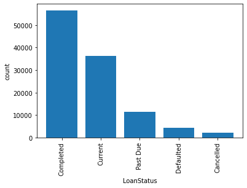

## Distribution of Debt to Income Ratios

The histogram is skewed to the right, despite some odd gaps and peaks, and has a general smooth slope after removing extreme ouliers. Most borrowers have a DtI of around 0.2, which is an acceptable value. Anything over 0.5 is not acceptable for DtI.

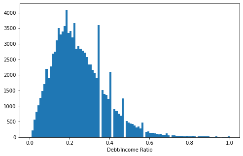

## Distribution of Borrower Rates

The distribution is generally right skewed, with some peaks to the right, making it multimodal. After dropping low outliers, there are still some very low borrower rates, which are legitimate, given factors like lower risk and higher credit score that make a borrower liekly to receive lower interest rates.

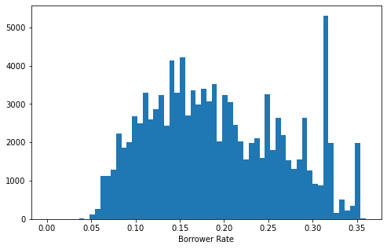

## Relationship between Loan Status and Income Range, and then Employment Status

Borrowers who are employed and higher income are more likely to be in the Complete or Current loan status.

[figure not shown]

## Relationship between Loan Status and Recommendations

1. The Recommendation distributions for LoanStatus are all thin slices at similar levels as the values are concentrated around 0 to 1. However, high outliers, are concentrated at Completed, showing that listings with more recommendations are more likely to have their loans cleared, making Recommendations a good predictor of LoanStatus.
2. One thing to note though is that Cancelled status has a higher concentration of outliers than Current. This needs further exploration outside this project as we don't know the different reasons why some loan listings were cancelled.

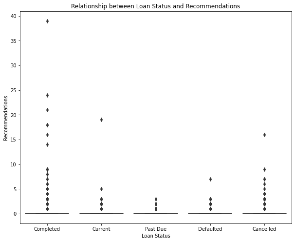

## Relationship between Loan Status, Debt to Income Ratio and Borrower Rate.

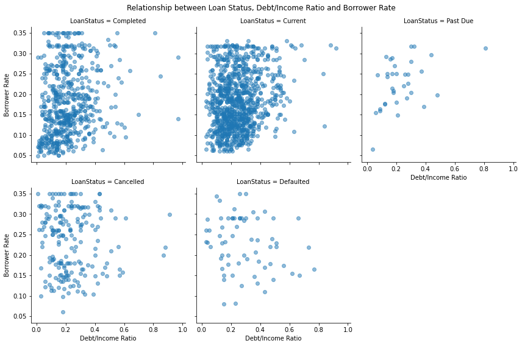